# Proper Press

Scott Woosley

Monday, July 06, 2015

### The Goal:

This projects goal is to predict the manner in which people did a specific exercise. This type of model can help those who workout using devices such as Jawbone Up, Nike FuelBand, and Fitbit with live assessments of their lifting proficieny without the aid of a trainer or workout buddy. Specifically this analysis focuses and whether people conducted barbell lifts correctly and incorrectly in 5 different ways.

### Variables to predict with.

There were 159 raw predictors and 1 dependent variable. The dependent variable included 5 factors as indicated in the goal. Many of the variables were empty and some had nothing to do with movement. A quick removal of those variables cut the potential predictors down to 52.

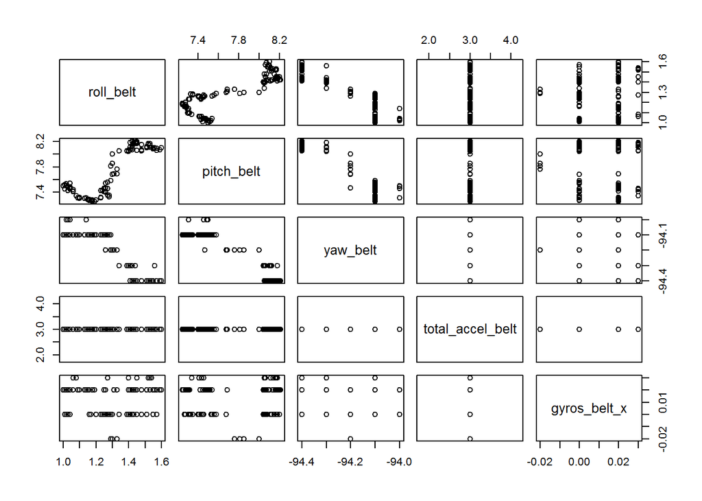

```r
pairs(workout2[1:100,1:5], pch = 21)
```

It was readily apparent from a quick review of just a handful of variables that many of them were highly correlated. I utilized a correlation matrix to further reduce the potential varaibles to 32.

```r
# ensure the results are repeatable
set.seed(7)
# define the control using a random forest selection function
control <- rfeControl(functions=rfFuncs, method="cv", number=10)
# run the RFE algorithm
results <- rfe(workout4[,1:32], workout4[,33], sizes=c(1:10), rfeControl=control)
```

```r
# summarize the results
print(results)
```

```
##
## Recursive feature selection
##
## Outer resampling method: Cross-Validated (10 fold)
##
## Resampling performance over subset size:
##
##  Variables Accuracy  Kappa AccuracySD  KappaSD Selected
##          1   0.4988 0.3514   0.009558 0.012589
##          2   0.7375 0.6673   0.009285 0.011607
##          3   0.8660 0.8303   0.010797 0.013683
##          4   0.9293 0.9106   0.009521 0.012068
##          5   0.9536 0.9413   0.007641 0.009680
##          6   0.9699 0.9619   0.005045 0.006383
##          7   0.9711 0.9635   0.003930 0.004971
##          8   0.9797 0.9743   0.003554 0.004498
##          9   0.9842 0.9800   0.003908 0.004943
##         10   0.9864 0.9828   0.003367 0.004261
##         32   0.9957 0.9946   0.001667 0.002109        *
##
## The top 5 variables (out of 32):
##    roll_belt, magnet_dumbbell_z, pitch_belt, roll_dumbbell, magnet_dumbbell_x
```

```r
# list the chosen features
predictors(results)
```

```
##  [1] "roll_belt"            "magnet_dumbbell_z"    "pitch_belt"
##  [4] "roll_dumbbell"        "magnet_dumbbell_x"    "pitch_forearm"
##  [7] "magnet_belt_y"        "magnet_forearm_z"     "roll_arm"
## [10] "total_accel_dumbbell" "yaw_arm"              "roll_forearm"
## [13] "gyros_arm_x"          "gyros_forearm_y"      "yaw_dumbbell"
## [16] "gyros_belt_z"         "accel_forearm_x"      "gyros_dumbbell_y"
## [19] "accel_forearm_z"      "gyros_dumbbell_x"     "accel_forearm_y"
## [22] "yaw_forearm"          "pitch_arm"            "accel_arm_x"
## [25] "total_accel_forearm"  "magnet_forearm_x"     "magnet_arm_y"
## [28] "pitch_dumbbell"       "gyros_belt_x"         "gyros_forearm_x"
## [31] "gyros_belt_y"         "gyros_arm_z"
```

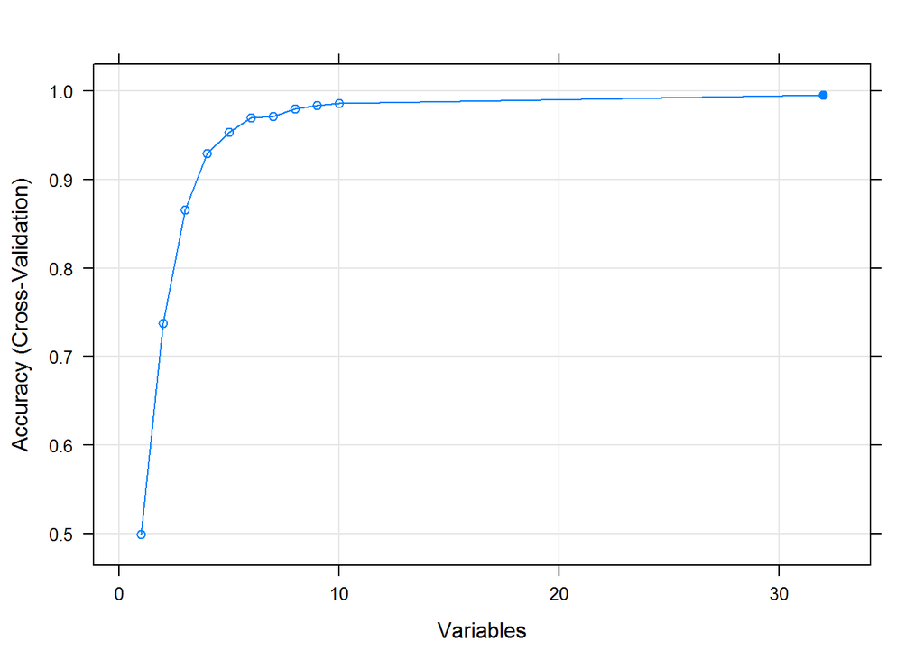

```r
# plot the results
plot(results, type=c("g", "o"))
```

### Describe how you built your model

I included the following variables:

```r
names(workout5[,-10])
```

```
## [1] "roll_belt"            "magnet_dumbbell_z"    "pitch_belt"
## [4] "pitch_forearm"        "magnet_dumbbell_x"    "roll_dumbbell"
## [7] "magnet_belt_y"        "magnet_forearm_z"     "total_accel_dumbbell"
```

Initially I tested a few random forests, but eventually settled on a Generalized Boosted Regression Model. It accurately predicted model results with only 9 predictors and no preprocessing. My attempts to use PCA did not result in favorable predictions. My model parsing(70% training, 30% testing) is listed below. As you can see roll_belt clearly holds a large amount of the influence with a gradual drop-off down to magnet_forearm_z.

```r
inTrain <- createDataPartition(y=workout5$classe,p=0.7, list=FALSE)

training <- workout5[inTrain,]
testing <- workout5[-inTrain,]

modFit3 <- train(training$classe~.,method="gbm", data=training)
```

```r
pred3 <- predict(modFit3, newdata=testing)
```

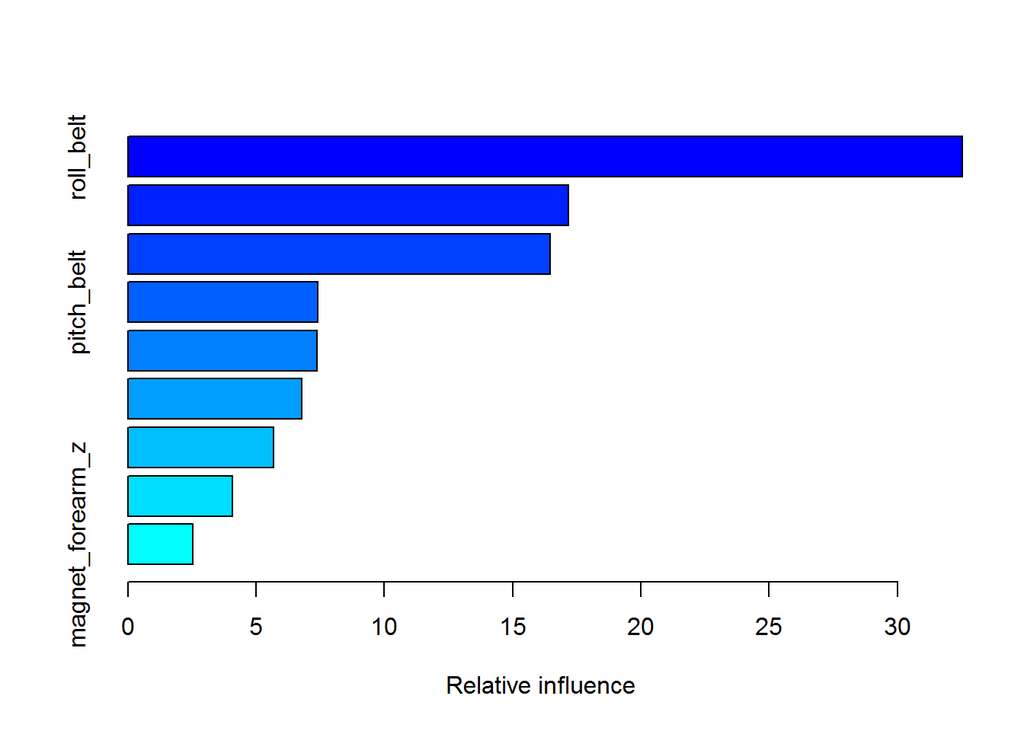

```
##                                       var   rel.inf
## roll_belt                       roll_belt 32.529643
## pitch_forearm               pitch_forearm 17.162012
## magnet_dumbbell_z       magnet_dumbbell_z 16.449569
## pitch_belt                     pitch_belt  7.405919
## magnet_dumbbell_x       magnet_dumbbell_x  7.368131
## roll_dumbbell               roll_dumbbell  6.787286
## magnet_belt_y               magnet_belt_y  5.679988
## total_accel_dumbbell total_accel_dumbbell  4.076724
## magnet_forearm_z         magnet_forearm_z  2.540727
```

```r
summary(modFit3)
```

```r
confusionMatrix(testing$classe, pred3)
```

```
## Confusion Matrix and Statistics
##
##           Reference
## Prediction    A    B    C    D    E
##          A 1602   23   25   18    6
##          B   61  984   62   29    3
##          C   15   40  920   46    5
##          D   13   13   57  878    3
##          E   14   11   29   26 1002
##
## Overall Statistics
##
##                Accuracy : 0.9152
##                  95% CI : (0.9078, 0.9222)
##     No Information Rate : 0.2897
##     P-Value [Acc > NIR] : < 2.2e-16
##
##                   Kappa : 0.8927
##  Mcnemar's Test P-Value : 3.861e-12
##
## Statistics by Class:
##
##                      Class: A Class: B Class: C Class: D Class: E
## Sensitivity            0.9396   0.9188   0.8417   0.8806   0.9833
## Specificity            0.9828   0.9678   0.9779   0.9824   0.9836
## Pos Pred Value         0.9570   0.8639   0.8967   0.9108   0.9261
## Neg Pred Value         0.9755   0.9817   0.9644   0.9758   0.9965
## Prevalence             0.2897   0.1820   0.1857   0.1694   0.1732
## Detection Rate         0.2722   0.1672   0.1563   0.1492   0.1703
## Detection Prevalence   0.2845   0.1935   0.1743   0.1638   0.1839
## Balanced Accuracy      0.9612   0.9433   0.9098   0.9315   0.9834
```

### Cross validation

I utilized a 10 k-fold cross validation in the selection of my variables in order to get a better prediction of which variables would likley predict well on the testing set.

### Out of sample error

The out of sample error is 1 minus the model accuracy when predicted on the test set so 1 - .9155 = ~8.5%. The test against the 20 test cases resulted in 1/20 errors = 5%

### Why I made the choices I did.

I made the choices I made based primarily on 2 factors: 1) Reducing the training time 2) Controlling for overfitting

### Predict on the 20 different test cases. I ran the predictions provided and achieved 19 out of 20 predictions.

```r
pml.testing <- read.csv("E:/Continuing Education/Data Scientist/Practical Machine Learning/project/pml-testing.csv")
pred4 <- predict(modFit3, newdata=pml.testing)
pred4
```

```
##  [1] B A A D A E D B A A B C B A E E A D B B
## Levels: A B C D E
```